# The Influence of Chemical Components on the Quality of Red Wine by Emma Harvey

```
## 'data.frame':    1599 obs. of  13 variables:
##  $ X                   : int  1 2 3 4 5 6 7 8 9 10 ...
##  $ fixed.acidity       : num  7.4 7.8 7.8 11.2 7.4 7.4 7.9 7.3 7.8 7.5 ...
##  $ volatile.acidity    : num  0.7 0.88 0.76 0.28 0.7 0.66 0.6 0.65 0.58 0.5 ...
##  $ citric.acid         : num  0 0 0.04 0.56 0 0 0.06 0 0.02 0.36 ...
##  $ residual.sugar      : num  1.9 2.6 2.3 1.9 1.9 1.8 1.6 1.2 2 6.1 ...
##  $ chlorides           : num  0.076 0.098 0.092 0.075 0.076 0.075 0.069 0.065 0.073 0.071 ...
##  $ free.sulfur.dioxide : num  11 25 15 17 11 13 15 15 9 17 ...
##  $ total.sulfur.dioxide: num  34 67 54 60 34 40 59 21 18 102 ...
##  $ density             : num  0.998 0.997 0.997 0.998 0.998 ...
##  $ pH                  : num  3.51 3.2 3.26 3.16 3.51 3.51 3.3 3.39 3.36 3.35 ...
##  $ sulphates           : num  0.56 0.68 0.65 0.58 0.56 0.56 0.46 0.47 0.57 0.8 ...
##  $ alcohol             : num  9.4 9.8 9.8 9.8 9.4 9.4 9.4 10 9.5 10.5 ...
##  $ quality             : int  5 5 5 6 5 5 5 7 7 5 ...
```

```
##        X          fixed.acidity   volatile.acidity  citric.acid
##  Min.   :   1.0   Min.   : 4.60   Min.   :0.1200   Min.   :0.000
##  1st Qu.: 400.5   1st Qu.: 7.10   1st Qu.:0.3900   1st Qu.:0.090
##  Median : 800.0   Median : 7.90   Median :0.5200   Median :0.260
##  Mean   : 800.0   Mean   : 8.32   Mean   :0.5278   Mean   :0.271
##  3rd Qu.:1199.5   3rd Qu.: 9.20   3rd Qu.:0.6400   3rd Qu.:0.420
##  Max.   :1599.0   Max.   :15.90   Max.   :1.5800   Max.   :1.000
##  residual.sugar     chlorides       free.sulfur.dioxide
##  Min.   : 0.900   Min.   :0.01200   Min.   : 1.00
##  1st Qu.: 1.900   1st Qu.:0.07000   1st Qu.: 7.00
##  Median : 2.200   Median :0.07900   Median :14.00
##  Mean   : 2.539   Mean   :0.08747   Mean   :15.87
##  3rd Qu.: 2.600   3rd Qu.:0.09000   3rd Qu.:21.00
##  Max.   :15.500   Max.   :0.61100   Max.   :72.00
##  total.sulfur.dioxide    density             pH          sulphates
##  Min.   :  6.00       Min.   :0.9901   Min.   :2.740   Min.   :0.3300
##  1st Qu.: 22.00       1st Qu.:0.9956   1st Qu.:3.210   1st Qu.:0.5500
##  Median : 38.00       Median :0.9968   Median :3.310   Median :0.6200
##  Mean   : 46.47       Mean   :0.9967   Mean   :3.311   Mean   :0.6581
##  3rd Qu.: 62.00       3rd Qu.:0.9978   3rd Qu.:3.400   3rd Qu.:0.7300
##  Max.   :289.00       Max.   :1.0037   Max.   :4.010   Max.   :2.0000
##     alcohol         quality
##  Min.   : 8.40   Min.   :3.000
##  1st Qu.: 9.50   1st Qu.:5.000
##  Median :10.20   Median :6.000
##  Mean   :10.42   Mean   :5.636
##  3rd Qu.:11.10   3rd Qu.:6.000
##  Max.   :14.90   Max.   :8.000
```

# Introduction

This report describes how the quality of red wine is affected by the chemical properties and contents of the wine. The data set used for this analysis was the “wineQualityRed” csv file, obtained from the Udacity website. The dataset contains information on 11 features of 1599 different red wines, and the quality was graded from 0 (very bad) to 10 (excellent), by three wine experts. Nine of the features provided for each wine were related to chemical composition (fixed acidity, volatile acidity, citric acid, residual sugar, chlorides, free and total sulfur dioxides, sulphates, alcohol) and two were related to the chemcial and physical properties of the wine (pH and density, respectively). EXploratory data analysis was carried out on this data set in order to gain insight into which of these features has the biggest impact on the quality of the red wines described here.

# Univariate Plots Section

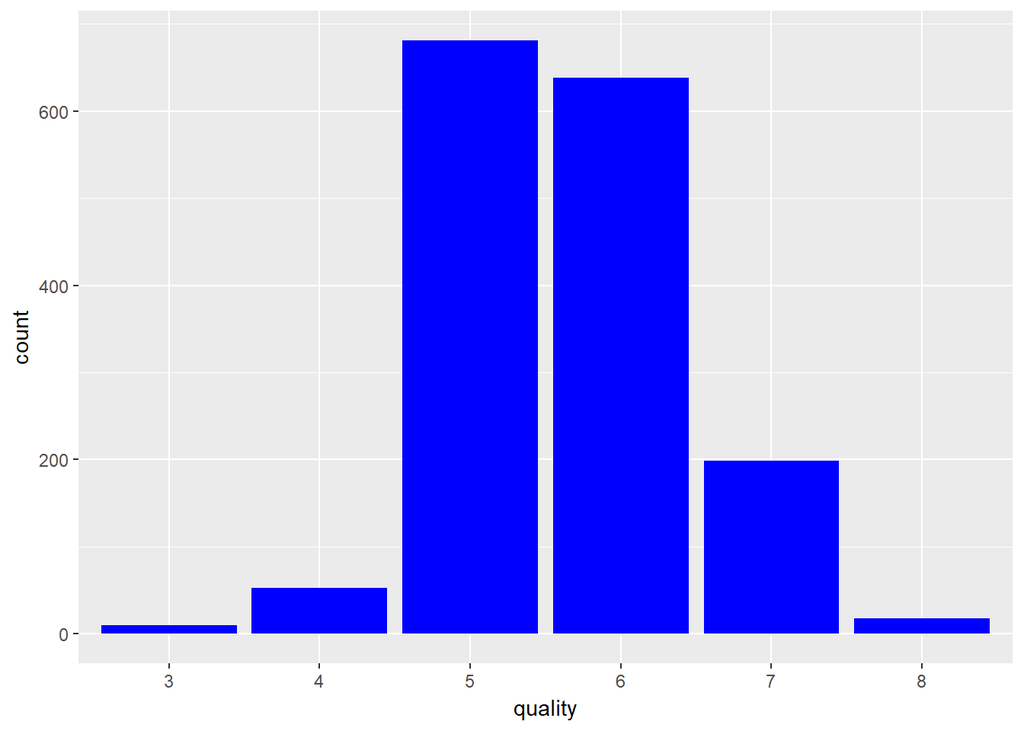

```
##   3   4   5   6   7   8
##  10  53 681 638 199  18
```

The quality variable was converted from a number to a categorical variable. It is clear from the bar chart that none of the wines were graded as low as 0, 1 or 2, and none of the wines tested received a top score of 9 or 10. The most common score for the red wine samples in this data set was 5.

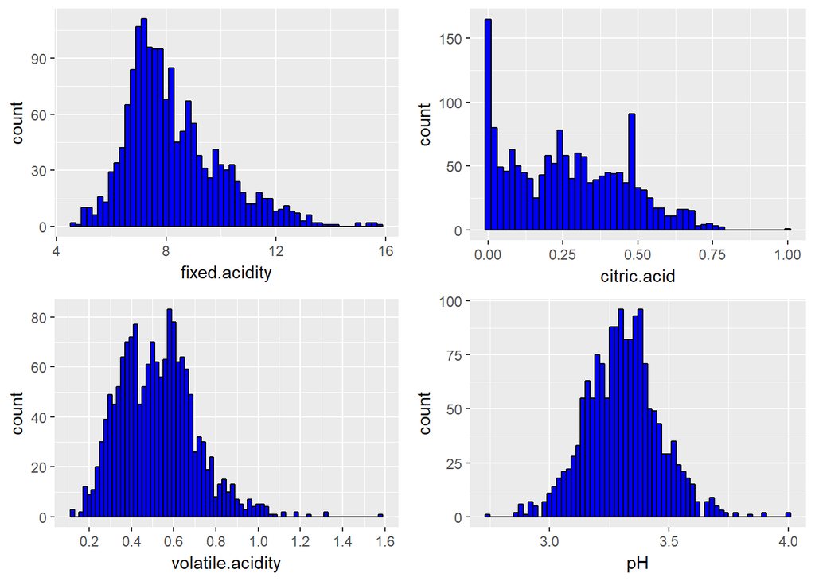

```
##    Min. 1st Qu.  Median    Mean 3rd Qu.    Max.
##    4.60    7.10    7.90    8.32    9.20   15.90
```

```
##    Min. 1st Qu.  Median    Mean 3rd Qu.    Max.
##   0.000   0.090   0.260   0.271   0.420   1.000
```

```
##    Min. 1st Qu.  Median    Mean 3rd Qu.    Max.
##  0.1200  0.3900  0.5200  0.5278  0.6400  1.5800
```

```
##    Min. 1st Qu.  Median    Mean 3rd Qu.    Max.
##   2.740   3.210   3.310   3.311   3.400   4.010
```

Acidity is a very important feature of wine as it provides the sour taste and imparts resistance to microbial infection. Total acidity is generally divided into two groups: the fixed acids and the volatile acids.[1](http://waterhouse.ucdavis.edu/whats-in-wine/fixed-acidity)

The most prevalent fixed acids found in wines are tartaric, malic, citric, and succinic, with levels typically ranging from 0 to 8,000 mg/L for the various acids.[1](http://waterhouse.ucdavis.edu/whats-in-wine/fixed-acidity) However, the histogram shows a long tail on the right of the plot and the mean fixed acidity concentration was 8.32 g/L, which is higher than expected.

Volatile acidity refers to volatile acids present in wine, which lead to wine spoilage. The most prevalent volatile acid in wine is acetic acid, but lactic, formic, butyric, and propionic acids can also be found. The average level of acetic acid is less than 400 mg/, in a new dry table wine, but the typical aroma threshold for acetic acid in red wine varies from 600 mg/L and 900 mg/L.[2](http://waterhouse.ucdavis.edu/whats-in-wine/volatile-acidity) There is evidence of bimodailty in the histogram of the volatile acid content recorded in this data set, with a peak at approximately 0.4 g/L (as expected for new dry table wine) and a second peak at around 0.6 g/L. Overall, volatile acid content remained below aroma threshhold of 0.9 g/L for the vast majority of the wine samples.

A plot of the pH data was also included here, as the pH is a measure of acidity in the wine. pH affects the color, stability to oxidation, and consequantly the overall lifespan of a wine.[1](http://waterhouse.ucdavis.edu/whats-in-wine/fixed-acidity) Quite a normal histogram was obtained for the pH values, with a mean of 3.31, which is within the expected pH range (2.5 to 4.5).[3](https://winefolly.com/review/understanding-acidity-in-wine)

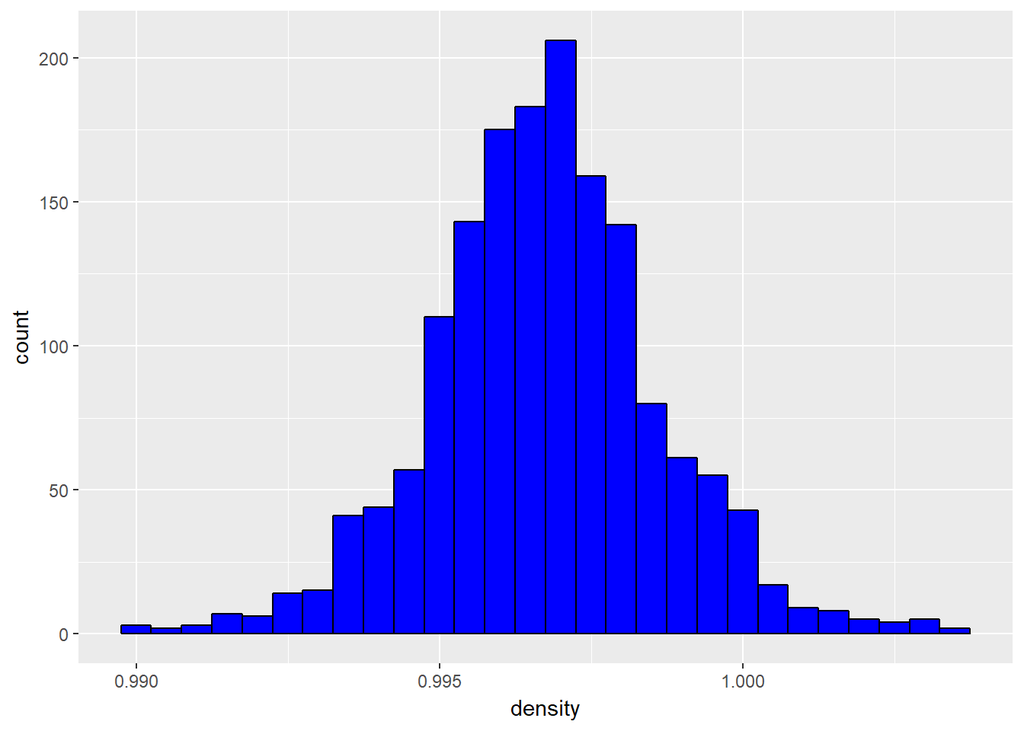

```
##    Min. 1st Qu.  Median    Mean 3rd Qu.    Max.
##  0.9901  0.9956  0.9968  0.9967  0.9978  1.0037
```

A normal histogram was obtained for the density values of the various wines, with a mean density of 0.9967.

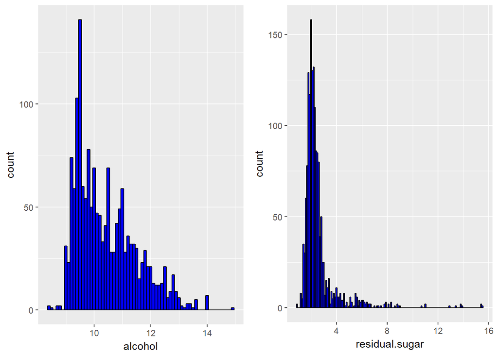

```
##    Min. 1st Qu.  Median    Mean 3rd Qu.    Max.
##    8.40    9.50   10.20   10.42   11.10   14.90
```

```
##    Min. 1st Qu.  Median    Mean 3rd Qu.    Max.
##   0.900   1.900   2.200   2.539   2.600  15.500
```

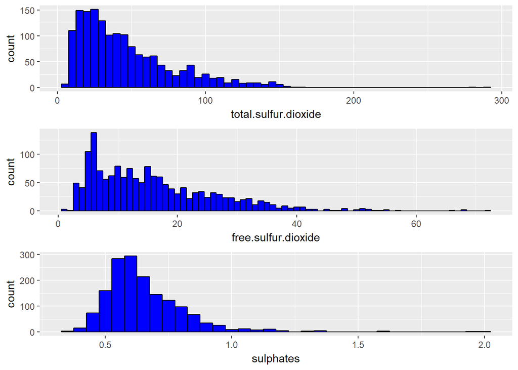

```
##    Min. 1st Qu.  Median    Mean 3rd Qu.    Max.
##    6.00   22.00   38.00   46.47   62.00  289.00
```

```
##    Min. 1st Qu.  Median    Mean 3rd Qu.    Max.
##    1.00    7.00   14.00   15.87   21.00   72.00
```

```
##    Min. 1st Qu.  Median    Mean 3rd Qu.    Max.
##  0.3300  0.5500  0.6200  0.6581  0.7300  2.0000
```

Sulphites are added to wine, to improve the quality of the wine.[6](https://www.sciencedirect.com/science/article/pii/S221418121400024X) Two classes of sulfites are found in wine: free and bound. It is the free sulfur dioxide that has the antioxidant and antimicrobial properties, making it an effective preservative for wine.[5](https://www.awri.com.au/industry_support/winemaking_resources/fining-stabilities/microbiological/avoidance/sulfur_dioxide/)

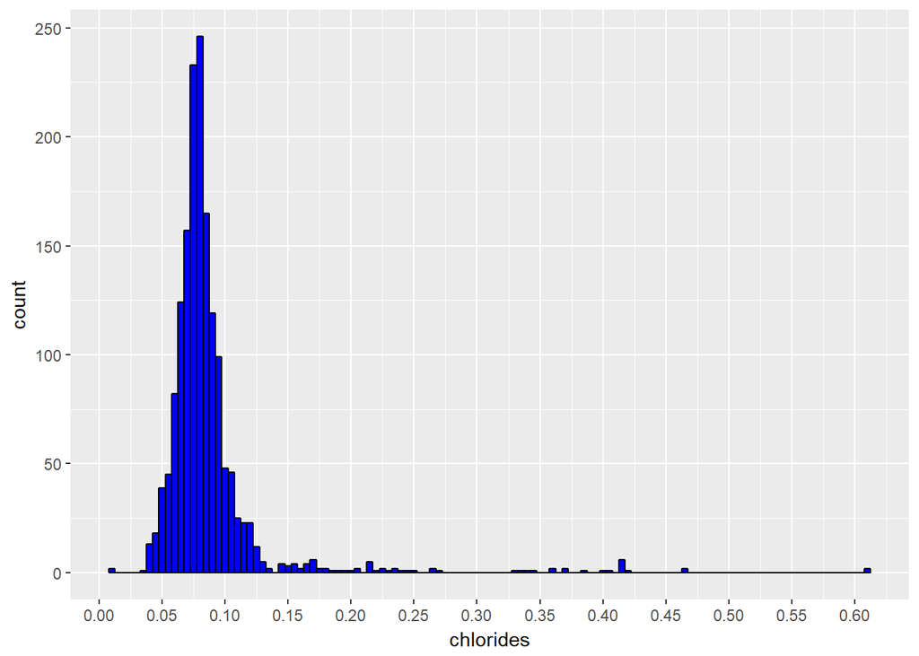

```
##    Min. 1st Qu.  Median    Mean 3rd Qu.    Max.
## 0.01200 0.07000 0.07900 0.08747 0.09000 0.61100
```

```
##    Mode   FALSE    TRUE
## logical      72    1527
```

Grapes abosrb mineral elements from the soil, which result in various concentrations of such elements in the wine. The mineral composition of a wine affects the color, clearness, flavor and aroma. The presence of chlorides in wine can give wine a salty taste, if present in high concentrations. Maximum concentrations of chlorides in wine vary from country to country, which can range from 0.20 g/L in Brazil, to 0.607 g/L in Australia (expressed as sodium chloride).[9](http://www.scielo.br/scielo.php?script=sci_arttext&pid=S0101-20612015000100095)

# Univariate Analysis

### What is the structure of your dataset?

The dataset contains 13 variables and 1599 observations. All of the varaibles are numerical, and are listed here:

1. X (numbering the observational rows)
2. fixed.acidity
3. volatile.acidity
4. citric.acid
5. residual.sugar
6. chlorides
7. free.sulfur.dioxide
8. total.sulfur.dioxide
9. denisty
10. pH
11. sulphates
12. alcohol
13. quality

### What is/are the main feature(s) of interest in your dataset?

The quality of the wine is the main variable of interest in the dataset, as the goal is to examine how the chemical properties of the wine effect the quality.

### What other features in the dataset do you think will help support your investigation into your feature(s) of interest?

The acidity, sulfur levels and chloride content are expected to help to determine the most important features in the quality of the wine.

### Did you create any new variables from existing variables in the dataset?

A new variable was not created. However, the quality variable was converted from a numberic to a categorical varaible, with 6 levels, in order to make it easier to compare the affect of the other varaibles on the quality of the wine.

### Of the features you investigated, were there any unusual distributions? Did you perform any operations on the data to tidy, adjust, or change the form of the data? If so, why did you do this?

Operations were not perfromed on the data as there was no apparant need for the data to be transformed in any way.

# Bivariate Plots Section

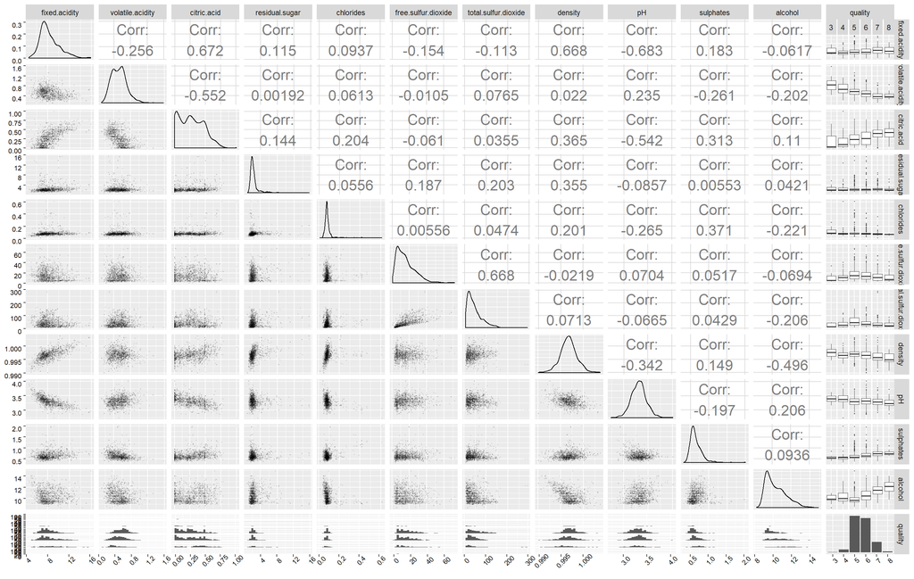

From the boxplots in the matrix, it appears that the volatile acid, citric acid, and alcohol content are correlated with the quality of the wine. The scatter plots show a linear relationship between fixed acids and citric acid, fixed acids and pH and fixed acids and density.

# Bivariate Analysis

## Acidity

### Acidity levels vs. pH

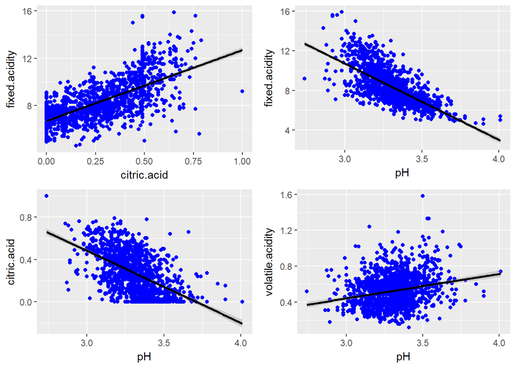

```
##
##  Pearson's product-moment correlation
##
## data:  redwine$fixed.acidity and redwine$citric.acid
## t = 36.234, df = 1597, p-value < 2.2e-16
## alternative hypothesis: true correlation is not equal to 0
## 95 percent confidence interval:
##  0.6438839 0.6977493
## sample estimates:
##       cor
## 0.6717034
```

```
##
##  Pearson's product-moment correlation
##
## data:  redwine$fixed.acidity and redwine$pH
## t = -37.366, df = 1597, p-value < 2.2e-16
## alternative hypothesis: true correlation is not equal to 0
## 95 percent confidence interval:
##  -0.7082857 -0.6559174
## sample estimates:
##        cor
## -0.6829782
```

```
##
##  Pearson's product-moment correlation
##
## data:  redwine$citric.acid and redwine$pH
## t = -25.767, df = 1597, p-value < 2.2e-16
## alternative hypothesis: true correlation is not equal to 0
## 95 percent confidence interval:
##  -0.5756337 -0.5063336
## sample estimates:
##        cor
## -0.5419041
```

```
##
##  Pearson's product-moment correlation
##
## data:  redwine$volatile.acidity and redwine$pH
## t = 9.659, df = 1597, p-value < 2.2e-16
## alternative hypothesis: true correlation is not equal to 0
## 95 percent confidence interval:
##  0.1880823 0.2807254
## sample estimates:
##       cor
## 0.2349373
```

As mentioned in the previous section, citric acid falls under the fixed acid category. As such, it is not surprising to see that as the citric acid content level increases, so does the concentration of total fixed acids, as shown in the scatterplot, with a linear correlation of 0.672.

The relationship between pH with fixed and volatile acids was investigated to see which group of acids had a higher impact on pH of the wine. A strong correlation was not observed between the volatile acidity levels and the pH, with a correlation coefficient of 0.235. However, a negative linear relationship was observed between the fixed acidity levels and pH, with correlation coefficient of -0.683, indicating that the pH of the wine increases as the fixed acidity level decreases. Consistently, a negative linear relationship was also observed between the pH and the citric acid content in the wine samples, albeit with a slightly lower correlation coefficient of -0.542.

### Acidity vs. Quality

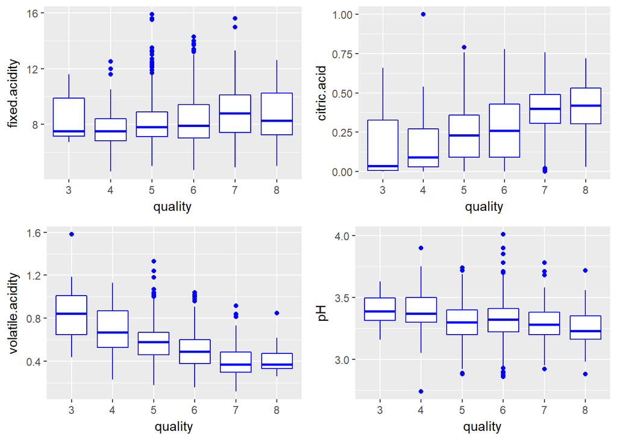

The variables related to the acidity of the wine were plotted against the quality rating of the wine samples, using boxplots, in order to establish which variables were most important in determing the wine quality. Acidity is an important feature of the wine as it provides the sour taste and imparts resistance to microbial infection.[1](http://waterhouse.ucdavis.edu/whats-in-wine/fixed-acidity) The boxplot of the fixed acidity levels vs. quality did not show a significant relationship between the two variables. On the other hand, it appears that, in general, as the citric acid levels increase so does the quality rating. This suggests that citric acid is one of the most important of the fixed acids with regards to it’s influence on the quality of the wine. Accordingly, the pH of the wine samples was found to decrease as the quality rating increased.  
With regards to the volatile acids, in general, the quality of the wine was found to decrease as the volatile acidity levels increased. This result is not a sursprising result as the volatile acids present in wine are known to lead to wine spoilage.[2](http://waterhouse.ucdavis.edu/whats-in-wine/volatile-acidity)

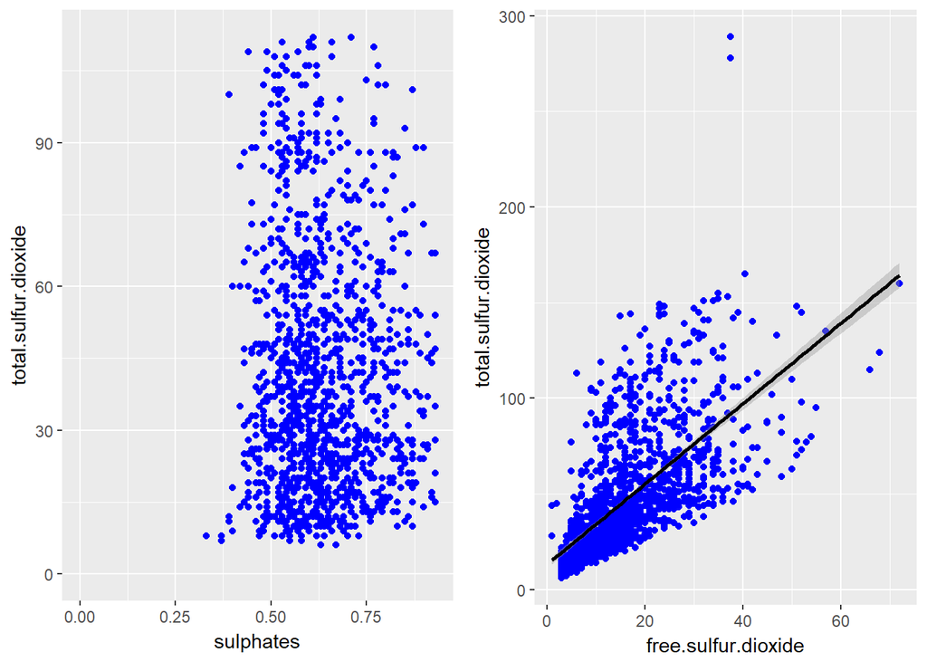

```
##
##  Pearson's product-moment correlation
##
## data:  redwine$total.sulfur.dioxide and redwine$free.sulfur.dioxide
## t = 35.84, df = 1597, p-value < 2.2e-16
## alternative hypothesis: true correlation is not equal to 0
## 95 percent confidence interval:
##  0.6395786 0.6939740
## sample estimates:
##       cor
## 0.6676665
```

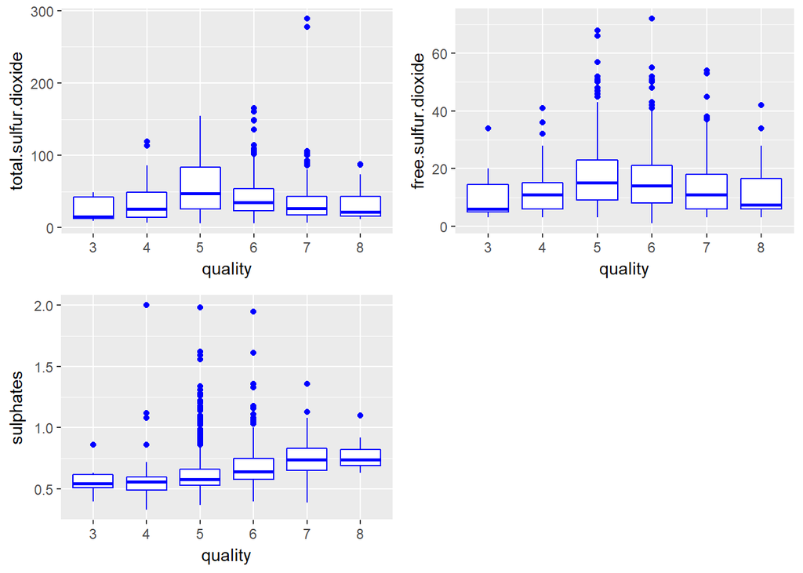

Sulfur dioxide is present in wine in free and bound form, the sum of which gives the total sulfur dioxide in wine. The total level of sulfur dioxide has a linear relationship with the free sulfur dioxide levels, with a correlation coefficient of 0.668. This is as expected, as the free form is yielded from the total sulfur dioxide amount added during the winemaking process.

On the other hand, the sulphate levels do not apper to be correlated to the sulfur dioxide levels.

As shown in the boxplots, the total sulfur dioxide levels do not seem to have a strong relationship with the quality of the wine. The interquartile ranges increase from a quality level of 3 to 5, and then decrease again from quality levels 6 to 8. A similar trend is observed for the boxplot of the free sufur dioxide versus quality.

However, sulphate concentration does show signs of a linear relationship with the quality of the wine: the quality increases as the sulphate level increases, albeit there are a number of outliers, particularly for quality levels 5 and 6.

## Alcohol & Residual Sugar vs. Quality

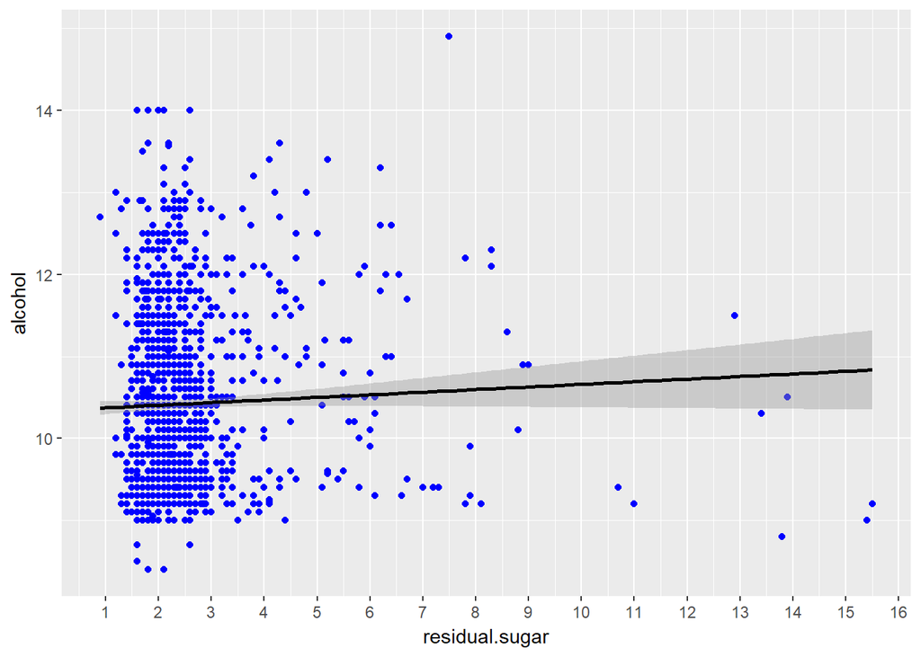

```
##
##  Pearson's product-moment correlation
##
## data:  redwine$residual.sugar and redwine$alcohol
## t = 1.6829, df = 1597, p-value = 0.09258
## alternative hypothesis: true correlation is not equal to 0
## 95 percent confidence interval:
##  -0.006960058  0.090909069
## sample estimates:
##        cor
## 0.04207544
```

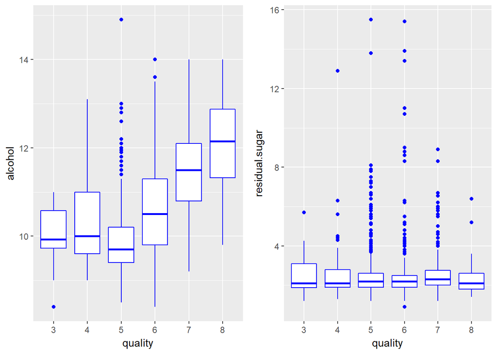

The natural sugars in the wine grapes are fermented into alcohol, and left over sugars which are not fermented are known as residual sugars.[4](https://winefolly.com/update/sugar-in-wine-misunderstanding) As such, a relationship between the levels of both varaibles was anticipated. However, the scatterplot between alcohol and residual sugar shows no linear relationship between them.

Investigations into the level of residual sugars on wine quality showed no relationship between the two variables. However, the boxplot shows a general trend between alcohol level and the quality of the wine: as the alcohol content increases, so does the quality of the wine.

## Chlorides vs. Quality

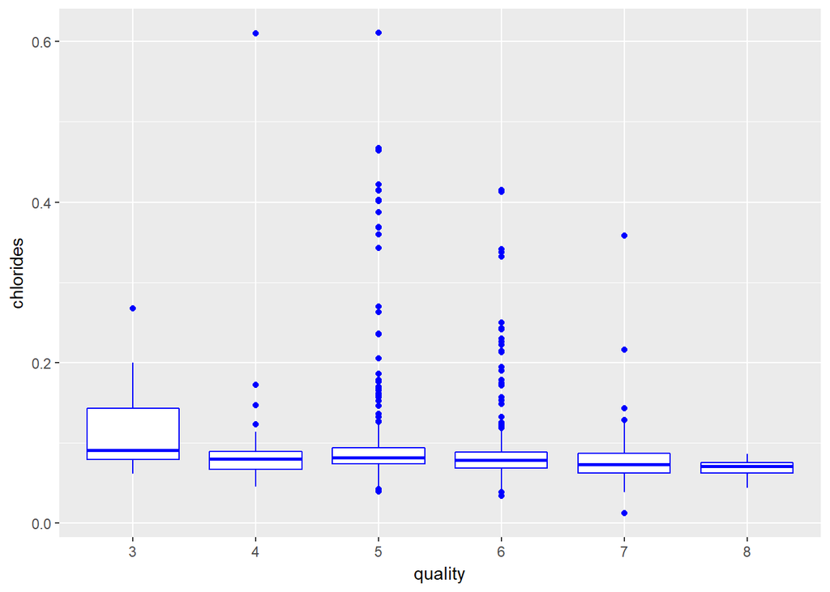

```
## # A tibble: 6 x 4
##   quality cl_median cl_max     n
##   <fct>       <dbl>  <dbl> <int>
## 1 3          0.0905 0.267     10
## 2 4          0.0800 0.610     53
## 3 5          0.0810 0.611    681
## 4 6          0.0780 0.415    638
## 5 7          0.0730 0.358    199
## 6 8          0.0705 0.0860    18
```

There is an apparant relationship between the chloride level in the wine and the quality rating, in which the quality increases as the chloride concentration decreases. For example, the median chlorides value is 0.0905 g/L for wines rated a quality level of 3, and the median chlorides value is 0.0705 g/L for wines rated a quality level of 8. However, there are many outliers, particularly in levels 5 and 6, with quite extreme concentrations of chlorides: the maximum chloride concentrations recorded at level 5 and 6 were 0.611 and 0.415 g/L respectively.

## Density

### Density vs. Quality

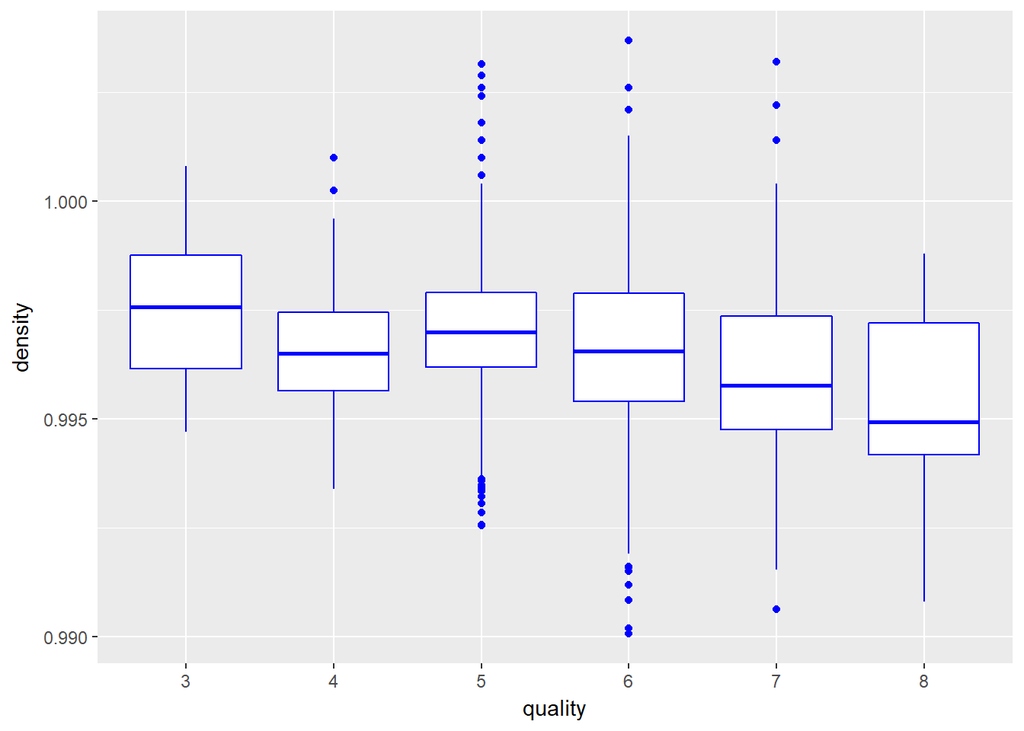

The boxplot appears to show a general trend that as the quality of the wine decreases, the density increases. Density is a physical property of the wine, and therefore, may be related to the concentration of one of the chemical components measured for these wine samples. So far, the quality of the wine has been connected to the levels of acidity, sulphates, alcohol and chlorides. Therefore, further investigation into how density relates to the concentration of each of these variables is described below.

### Density vs. Other Variables

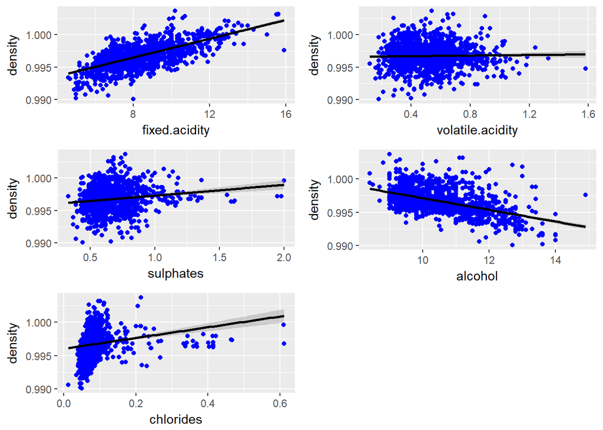

```
##
##  Pearson's product-moment correlation
##
## data:  redwine$density and redwine$fixed.acidity
## t = 35.877, df = 1597, p-value < 2.2e-16
## alternative hypothesis: true correlation is not equal to 0
## 95 percent confidence interval:
##  0.6399847 0.6943302
## sample estimates:
##       cor
## 0.6680473
```

```
##
##  Pearson's product-moment correlation
##
## data:  redwine$density and redwine$volatile.acidity
## t = 0.88044, df = 1597, p-value = 0.3788
## alternative hypothesis: true correlation is not equal to 0
## 95 percent confidence interval:
##  -0.02702409  0.07097074
## sample estimates:
##        cor
## 0.02202623
```

```
##
##  Pearson's product-moment correlation
##
## data:  redwine$density and redwine$sulphates
## t = 6.0012, df = 1597, p-value = 2.418e-09
## alternative hypothesis: true correlation is not equal to 0
## 95 percent confidence interval:
##  0.1002148 0.1961000
## sample estimates:
##       cor
## 0.1485064
```

```
##
##  Pearson's product-moment correlation
##
## data:  redwine$density and redwine$alcohol
## t = -22.838, df = 1597, p-value < 2.2e-16
## alternative hypothesis: true correlation is not equal to 0
## 95 percent confidence interval:
##  -0.5322547 -0.4583061
## sample estimates:
##        cor
## -0.4961798
```

```
##
##  Pearson's product-moment correlation
##
## data:  redwine$density and redwine$chlorides
## t = 8.1842, df = 1597, p-value = 5.541e-16
## alternative hypothesis: true correlation is not equal to 0
## 95 percent confidence interval:
##  0.1531171 0.2472220
## sample estimates:
##       cor
## 0.2006323
```

```
##
##  Pearson's product-moment correlation
##
## data:  density and chlorides
## t = 15.33, df = 1556, p-value < 2.2e-16
## alternative hypothesis: true correlation is not equal to 0
## 95 percent confidence interval:
##  0.3183059 0.4046248
## sample estimates:
##       cor
## 0.3622418
```

### Talk about some of the relationships you observed in this part of the investigation. How did the feature(s) of interest vary with other features in the dataset?

The acidic properties of the wine were found to effect the quality of the wine. In particular, as the citric acid levels increased, and the pH decreased, the quality of the wine was found to increase. On the other hand, the volatile acidity had the opposite effect, with the wine quality decreasing with increasing levels of volatile acids. With regards to the sulphite content, the quality of the wine was found to have a positive linear relationship with the sulpahte content, however a clear effect of total and free sulfur dioxides was not observed.

The alcohol level in the wine was found to have a strong relationship with wine quality: increasing alcohol correlated with an increase in quality level.

The level of residual sugars did not appear to have a significant effect on the quality of the wine, which was unexpected, as I would have considered the sweetness of the sugar to effect the taste of the wine, and therefore, the quality level.

Finally, the chloride content showed a trend of increasing quality with decreasing chloride levels, although there were many outliers present.

### Did you observe any interesting relationships between the other features (not the main feature(s) of interest)?

The pH of the wine was found to be decrease as the fixed acidity levels increased, and hence the citric acid concentration, increased. However, the volatile acid content was not found to have a significant effect on the pH of the wine.

Free sulphur dioxide content was found to increase with increasing total sulfur dioxide levels, as expected. However, the sulphate content did not show any relationship with the sulfur dioxide levels. This was not expected as the presence of sulphates could be a consequence of oxidised sulfur dioxide molecules.

The concetration of alcohol and residual sugar in the wine was also not found to be related. This was not anticapated as the residual sugar is left over sugar which did not ferment into alcohol, so I would have expected these two variables to have a negative linear relationship.

Density was found to decrease with increasing wine quality. Consequently, the relationship between density and some of the chemical components, which were found to be correlated to wine quality, was investigated in order to explain this result. The strongest correlations were found between alcohol and density, and fixed acidity and density, with correlation coefficients of -0.496 and 0.668, respectively.

### What was the strongest relationship you found?

The strongest relationship appears to be between alcohol and quality, and volatile acidity and quality. In the case of the alcohol content, the box plot showed relatively big differences in the median values of alcohol content at the higher quality levels (6, 7 and 8). In the case of the volatile acidity, the median concentrations were found to decrease steadily for quality levels 3 to 7. Therefore, alcohol and volatile acid content could potentially be used as good indicators for a high quality of wine.

# Multivariate Plots Section

## Alcohol vs. Quality vs. Other Variables

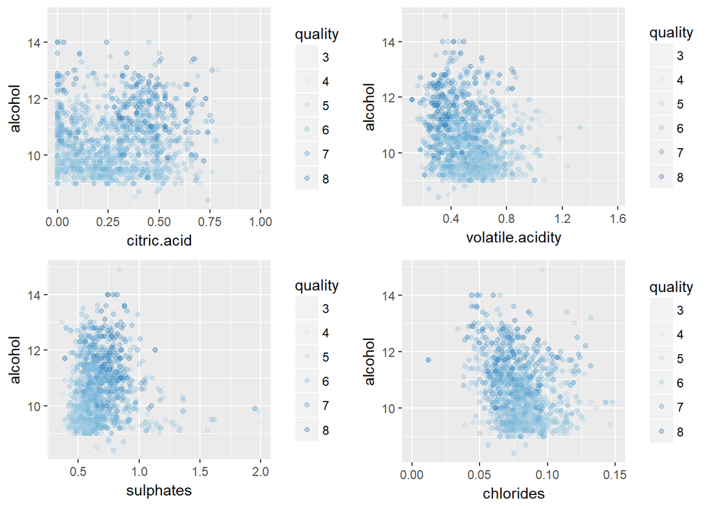

```
##    Mode   FALSE    TRUE
## logical      67    1532
```

```
##
##  Pearson's product-moment correlation
##
## data:  redwine$alcohol and redwine$citric.acid
## t = 4.4188, df = 1597, p-value = 1.059e-05
## alternative hypothesis: true correlation is not equal to 0
## 95 percent confidence interval:
##  0.06121189 0.15807276
## sample estimates:
##       cor
## 0.1099032
```

```
##
##  Pearson's product-moment correlation
##
## data:  redwine$alcohol and redwine$volatile.acidity
## t = -8.2546, df = 1597, p-value = 3.155e-16
## alternative hypothesis: true correlation is not equal to 0
## 95 percent confidence interval:
##  -0.2488416 -0.1548020
## sample estimates:
##       cor
## -0.202288
```

```
##
##  Pearson's product-moment correlation
##
## data:  redwine$alcohol and redwine$sulphates
## t = 3.7568, df = 1597, p-value = 0.0001783
## alternative hypothesis: true correlation is not equal to 0
## 95 percent confidence interval:
##  0.04477906 0.14196454
## sample estimates:
##        cor
## 0.09359475
```

```
##
##  Pearson's product-moment correlation
##
## data:  redwine$alcohol and redwine$chlorides
## t = -9.0617, df = 1597, p-value < 2.2e-16
## alternative hypothesis: true correlation is not equal to 0
## 95 percent confidence interval:
##  -0.2672644 -0.1740057
## sample estimates:
##        cor
## -0.2211405
```

These scatterplots show the expected general trends: 1) As alcohol content increases, and citric acid concentreation increases, quality increases. 2) As alcohol content increases, and volatile acidity decreases, quality increases. 3) As alcohol content increases, and sulphate concentreation increases, quality increases. 4) As alcohol content increases, and chloride content decreases, quality increases.

The strongest relationship with alcohol content appears to be with volatile acidity and chloride content, with correlation coeffiecients of -0.202 and -0.221 obtained, respectively.

## Volatile Acidity vs. Quality vs. Other Variables

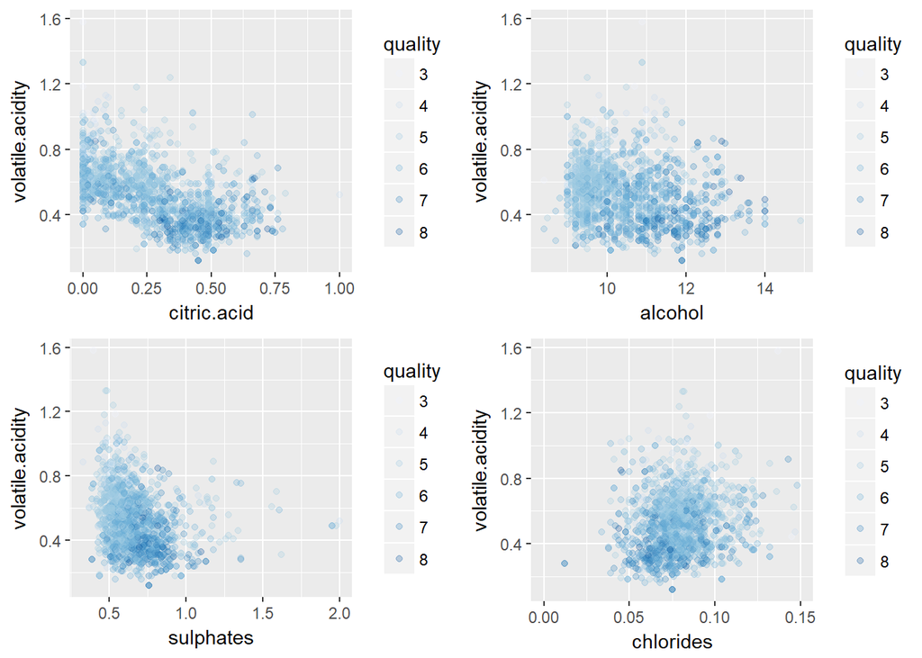

```
##
##  Pearson's product-moment correlation
##
## data:  redwine$volatile.acidity and redwine$citric.acid
## t = -26.489, df = 1597, p-value < 2.2e-16
## alternative hypothesis: true correlation is not equal to 0
## 95 percent confidence interval:
##  -0.5856550 -0.5174902
## sample estimates:
##        cor
## -0.5524957
```

```
##
##  Pearson's product-moment correlation
##
## data:  redwine$volatile.acidity and redwine$alcohol
## t = -8.2546, df = 1597, p-value = 3.155e-16
## alternative hypothesis: true correlation is not equal to 0
## 95 percent confidence interval:
##  -0.2488416 -0.1548020
## sample estimates:
##       cor
## -0.202288
```

```
##
##  Pearson's product-moment correlation
##
## data:  redwine$volatile.acidity and redwine$sulphates
## t = -10.804, df = 1597, p-value < 2.2e-16
## alternative hypothesis: true correlation is not equal to 0
## 95 percent confidence interval:
##  -0.3060917 -0.2147125
## sample estimates:
##        cor
## -0.2609867
```

```
##
##  Pearson's product-moment correlation
##
## data:  redwine$volatile.acidity and redwine$chlorides
## t = 2.4542, df = 1597, p-value = 0.01422
## alternative hypothesis: true correlation is not equal to 0
## 95 percent confidence interval:
##  0.01231363 0.10998841
## sample estimates:
##        cor
## 0.06129777
```

From the bivariate investigations in the previous section, volatile acidity also appeared to have a strong relationship with quality. Therefore, the volatile acid levels were plotted against the other four variables (citric acid, alcohol, sulphates and chlorides), and the points were coloured by the quality level. As mentioned above, some extreme outliers in the chlorides data were omitted from the plot here also.

These scatterplots show the expected general trends: 1) As volatile acid content decreases, and citric acid concentreation increases, quality increases. 2) As volatile acid content decreases, and alcohol content increases, quality increases. 3) As volatile acid content decreases, and sulphate concentreation increases, quality increases. 4) As volatile acid content decreases, and chloride content decreases, quality increases.

In contrast to the alcohol plots above, the strongest correlations observed for the volatile acidity content were with the citric acid concentration (corr coeff. = -0.552) and the sulphate content (corr. coeff. = -0.261).

## Linear Regression Models

```
##
## Calls:
## m1: lm(formula = (alcohol ~ quality), data = redwine)
## m2: lm(formula = alcohol ~ quality + volatile.acidity, data = redwine)
## m3: lm(formula = alcohol ~ quality + volatile.acidity + citric.acid,
##     data = redwine)
## m4: lm(formula = alcohol ~ quality + volatile.acidity + citric.acid +
##     sulphates, data = redwine)
## m5: lm(formula = alcohol ~ quality + volatile.acidity + citric.acid +
##     sulphates + chlorides, data = redwine)
##
## ==========================================================================================
##                          m1            m2            m3            m4            m5
## ------------------------------------------------------------------------------------------
##   (Intercept)           9.955***     10.124***     10.210***     10.365***     10.343***
##                        (0.289)       (0.314)       (0.330)       (0.340)       (0.335)
##   quality: 4/3          0.310         0.274         0.260         0.264         0.169
##                        (0.315)       (0.316)       (0.317)       (0.316)       (0.311)
##   quality: 5/3         -0.055        -0.114        -0.128        -0.123        -0.210
##                        (0.291)       (0.294)       (0.295)       (0.294)       (0.290)
##   quality: 6/3          0.675*        0.600*        0.585*        0.601*        0.470
##                        (0.291)       (0.296)       (0.297)       (0.297)       (0.292)
##   quality: 7/3          1.511***      1.419***      1.409***      1.435***      1.238***
##                        (0.296)       (0.304)       (0.304)       (0.304)       (0.300)
##   quality: 8/3          2.139***      2.051***      2.044***      2.077***      1.827***
##                        (0.360)       (0.366)       (0.366)       (0.366)       (0.362)
##   volatile.acidity                   -0.191        -0.265        -0.281        -0.035
##                                      (0.139)       (0.163)       (0.163)       (0.164)
##   citric.acid                                      -0.123        -0.068         0.178
##                                                    (0.142)       (0.145)       (0.146)
##   sulphates                                                      -0.263         0.192
##                                                                  (0.145)       (0.155)
##   chlorides                                                                    -4.055***
##                                                                                (0.549)
## ------------------------------------------------------------------------------------------
##   R-squared             0.267         0.268         0.268         0.269         0.294
##   adj. R-squared        0.264         0.265         0.265         0.266         0.290
##   sigma                 0.914         0.914         0.914         0.913         0.898
##   F                   115.855        96.913        83.163        73.284        73.408
##   p                     0.000         0.000         0.000         0.000         0.000
##   Log-likelihood    -2122.112     -2121.166     -2120.790     -2119.135     -2092.112
##   Deviance           1330.827      1329.253      1328.628      1325.880      1281.815
##   AIC                4258.224      4258.332      4259.580      4258.269      4206.224
##   BIC                4295.864      4301.349      4307.974      4312.041      4265.373
##   N                  1599          1599          1599          1599          1599
## ==========================================================================================
```

```
##
## Calls:
## m6: lm(formula = (volatile.acidity ~ quality), data = redwine)
## m7: lm(formula = volatile.acidity ~ quality + alcohol, data = redwine)
## m8: lm(formula = volatile.acidity ~ quality + alcohol + citric.acid,
##     data = redwine)
## m9: lm(formula = volatile.acidity ~ quality + alcohol + citric.acid +
##     sulphates, data = redwine)
## m10: lm(formula = volatile.acidity ~ quality + alcohol + citric.acid +
##     sulphates + chlorides, data = redwine)
##
## ========================================================================================
##                        m6            m7            m8            m9           m10
## ----------------------------------------------------------------------------------------
##   (Intercept)         0.885***      0.946***      1.024***      1.054***      0.959***
##                      (0.052)       (0.069)       (0.059)       (0.060)       (0.060)
##   quality: 4/3       -0.191***     -0.189***     -0.187***     -0.186***     -0.164***
##                      (0.057)       (0.057)       (0.048)       (0.048)       (0.047)
##   quality: 5/3       -0.307***     -0.308***     -0.275***     -0.273***     -0.248***
##                      (0.052)       (0.052)       (0.045)       (0.045)       (0.044)
##   quality: 6/3       -0.387***     -0.383***     -0.336***     -0.332***     -0.301***
##                      (0.052)       (0.052)       (0.045)       (0.045)       (0.044)
##   quality: 7/3       -0.481***     -0.471***     -0.379***     -0.372***     -0.333***
##                      (0.053)       (0.054)       (0.046)       (0.046)       (0.045)
##   quality: 8/3       -0.461***     -0.448***     -0.348***     -0.340***     -0.297***
##                      (0.065)       (0.066)       (0.056)       (0.056)       (0.055)
##   alcohol                          -0.006        -0.006        -0.007        -0.001
##                                    (0.005)       (0.004)       (0.004)       (0.004)
##   citric.acid                                    -0.452***     -0.441***     -0.464***
##                                                  (0.019)       (0.019)       (0.019)
##   sulphates                                                    -0.049*       -0.122***
##                                                                (0.022)       (0.024)
##   chlorides                                                                   0.674***
##                                                                              (0.084)
## ----------------------------------------------------------------------------------------
##   R-squared           0.161         0.161         0.389         0.391         0.415
##   adj. R-squared      0.158         0.158         0.387         0.388         0.412
##   sigma               0.164         0.164         0.140         0.140         0.137
##   F                  60.914        51.104       144.939       127.754       125.328
##   p                   0.000         0.000         0.000         0.000         0.000
##   Log-likelihood    621.832       622.778       876.340       878.823       910.813
##   Deviance           43.012        42.961        31.285        31.188        29.965
##   AIC             -1229.663     -1229.555     -1734.680     -1737.647     -1799.625
##   BIC             -1192.023     -1186.538     -1686.286     -1683.875     -1740.477
##   N                1599          1599          1599          1599          1599
## ========================================================================================
```

```
##
## Calls:
## m11: lm(formula = (volatile.acidity ~ quality), data = redwine)
## m12: lm(formula = volatile.acidity ~ quality + citric.acid, data = redwine)
## m13: lm(formula = volatile.acidity ~ quality + citric.acid + chlorides,
##     data = redwine)
## m14: lm(formula = volatile.acidity ~ quality + citric.acid + chlorides +
##     sulphates, data = redwine)
## m15: lm(formula = volatile.acidity ~ quality + citric.acid + chlorides +
##     sulphates + alcohol, data = redwine)
##
## ========================================================================================
##                       m11           m12           m13           m14           m15
## ----------------------------------------------------------------------------------------
##   (Intercept)         0.885***      0.962***      0.904***      0.950***      0.959***
##                      (0.052)       (0.044)       (0.045)       (0.045)       (0.060)
##   quality: 4/3       -0.191***     -0.189***     -0.173***     -0.164***     -0.164***
##                      (0.057)       (0.048)       (0.048)       (0.047)       (0.047)
##   quality: 5/3       -0.307***     -0.275***     -0.257***     -0.247***     -0.248***
##                      (0.052)       (0.045)       (0.044)       (0.044)       (0.044)
##   quality: 6/3       -0.387***     -0.341***     -0.318***     -0.301***     -0.301***
##                      (0.052)       (0.045)       (0.044)       (0.044)       (0.044)
##   quality: 7/3       -0.481***     -0.388***     -0.358***     -0.334***     -0.333***
##                      (0.053)       (0.046)       (0.045)       (0.045)       (0.045)
##   quality: 8/3       -0.461***     -0.362***     -0.327***     -0.298***     -0.297***
##                      (0.065)       (0.055)       (0.055)       (0.055)       (0.055)
##   citric.acid                      -0.452***     -0.483***     -0.464***     -0.464***
##                                    (0.019)       (0.019)       (0.019)       (0.019)
##   chlorides                                       0.515***      0.677***      0.674***
##                                                  (0.077)       (0.082)       (0.084)
##   sulphates                                                    -0.122***     -0.122***
##                                                                (0.024)       (0.024)
##   alcohol                                                                    -0.001
##                                                                              (0.004)
## ----------------------------------------------------------------------------------------
##   R-squared           0.161         0.388         0.405         0.415         0.415
##   adj. R-squared      0.158         0.386         0.403         0.412         0.412
##   sigma               0.164         0.140         0.138         0.137         0.137
##   F                  60.914       168.484       154.891       141.073       125.328
##   p                   0.000         0.000         0.000         0.000         0.000
##   Log-likelihood    621.832       875.018       897.436       910.789       910.813
##   Deviance           43.012        31.337        30.471        29.966        29.965
##   AIC             -1229.663     -1734.036     -1776.872     -1801.578     -1799.625
##   BIC             -1192.023     -1691.019     -1728.478     -1747.807     -1740.477
##   N                1599          1599          1599          1599          1599
## ========================================================================================
```

Three different linear regression models were employed in an attempt to identify the most important variables in predicing wine quality. The order in which the 5 variables being investigate, were added to the list, are as follows:

1. Quality vs. alcohol, volatile acidity, citric acid, sulphates, chlorides.
2. Quality vs. volatile acidity, alcohol, citric acid, sulphates, chlorides
3. Quality vs. volatile acidity, citric acid, chlorides, sulphates, alcohol

### Adjusted R-Squared

A summary of the adjusted R-squared values are list below, for each of the 3 models.

1. adj. R-squared 0.264 0.265 0.265 0.266 0.290
2. adj. R-squared 0.158 0.158 0.387 0.388 0.412
3. adj. R-squared 0.158 0.386 0.403 0.412 0.412

# Multivariate Analysis

### Talk about some of the relationships you observed in this part of the investigation. Were there features that strengthened each other in terms of looking at your feature(s) of interest?

Alcohol and volatile acidity were the two main features which appeared to have the strongest correlation with the quality of the wine. The chloride, sulphate and citric acid levels were also found to be related to the quality, albeit weaker, as described in the bivariant section. Therefore, multivariant scatter plots were created to explore the realtionship between 1) aclohol, and the other four features and 2) volatile acidity, and the other four features. In each plot, the points were colored by the quality level, in order to explore the relationship between all 3 varaibles.

### Were there any interesting or surprising interactions between features?

The correlation between alcohol levels with the volatile acidity and chloride levels was a bit surprsing as there is not a clear connection between the content of each. This correlation might be explained from the fact that a combination of each feature, at a particular level, can lead to a better quality of wine, as the data suggest.

### OPTIONAL: Did you create any models with your dataset? Discuss the strengths and limitations of your model.

# Final Plots and Summary

### Plot One

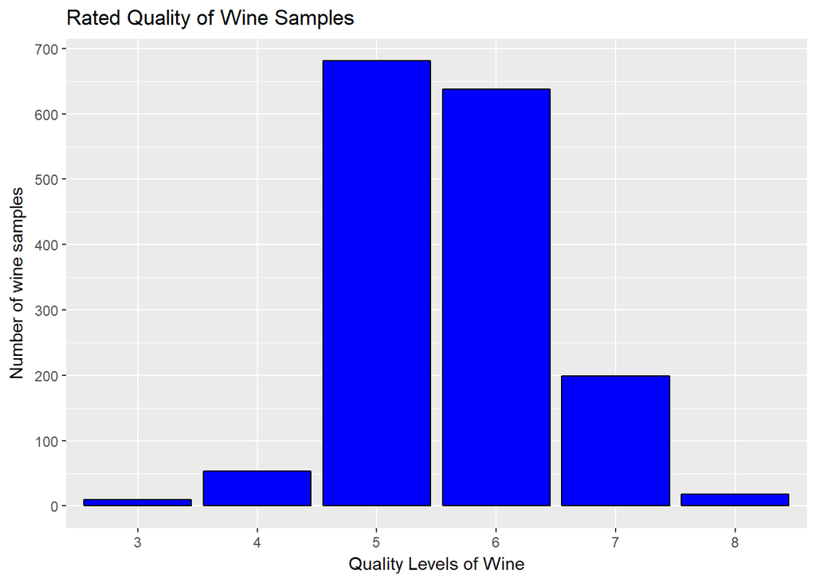

```
##   3   4   5   6   7   8
##  10  53 681 638 199  18
```

```
## # A tibble: 6 x 3
##   quality count `round(Percentage = (count/sum(count)) * 100)`
##   <fct>   <int>                                          <dbl>
## 1 3          10                                             1.
## 2 4          53                                             3.
## 3 5         681                                            43.
## 4 6         638                                            40.
## 5 7         199                                            12.
## 6 8          18                                             1.
```

### Description One

The histogram shows the distribution of 1599 wine samples, which were rated by their quality, from levels 0 to 10. The lowest rating given to a wine was 3, and the highest was 8. The majority of the wine samples were given a quality rating of 5 or 6 (43 and 40 %, respectively).

### Plot Two

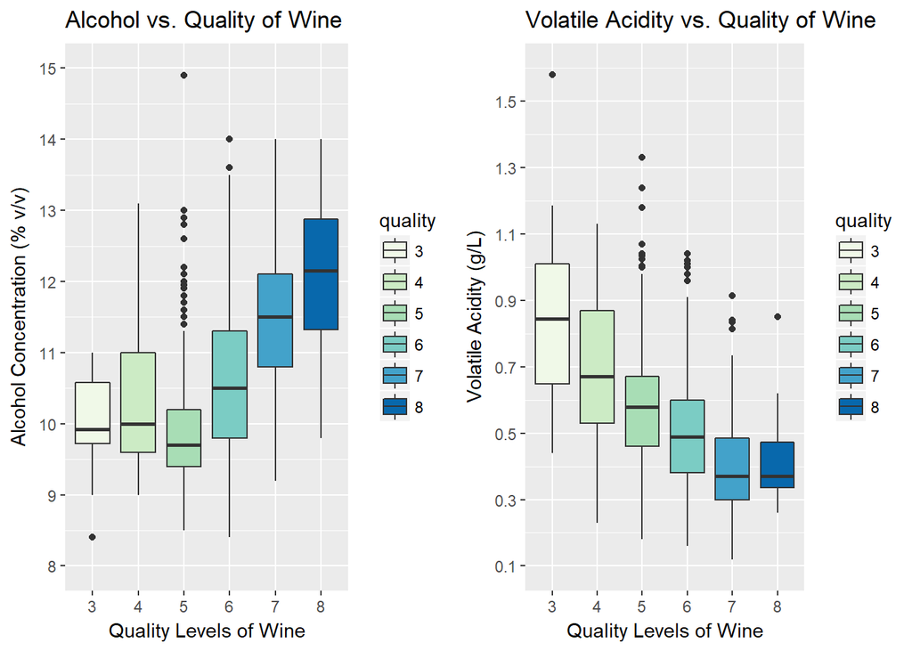

```
##    Min. 1st Qu.  Median    Mean 3rd Qu.    Max.
##    8.40    9.50   10.20   10.42   11.10   14.90
```

```
##    Min. 1st Qu.  Median    Mean 3rd Qu.    Max.
##  0.1200  0.3900  0.5200  0.5278  0.6400  1.5800
```

### Description Two

The boxplot (left) above shows that the quality of wine appears to be related to the % of alcohol in the wine. The lower wine quality levels (5 and below) seem to have similar levels of alcohol, with median values of approximately 10 or less, although there are a number of outliers at level 5. However, as the quality of wine increases to levels 6, 7 and 8, so does the concentration of alcohol, indicating that better quality wines have a higher level of alcohol.

The concentration of volatile acids shows a negative linear realtionship with the wine quality (boxplot right): as the volatile acid content decreases, the quality of the wine increases.

### Plot Three

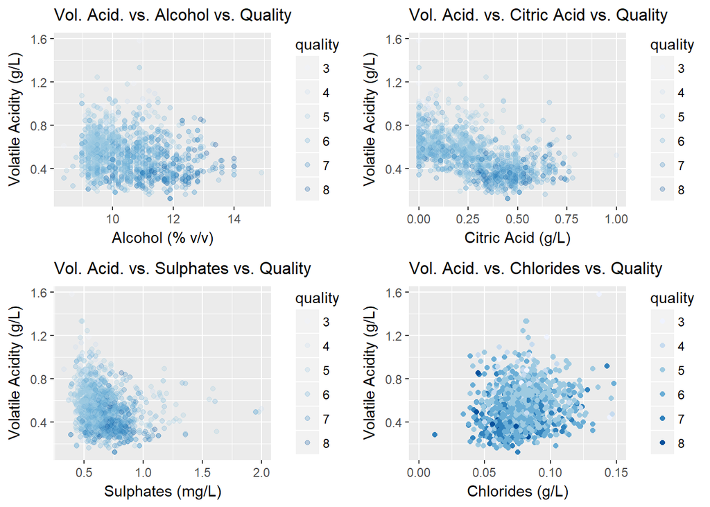

```
##
##  Pearson's product-moment correlation
##
## data:  redwine$volatile.acidity and redwine$alcohol
## t = -8.2546, df = 1597, p-value = 3.155e-16
## alternative hypothesis: true correlation is not equal to 0
## 95 percent confidence interval:
##  -0.2488416 -0.1548020
## sample estimates:
##       cor
## -0.202288
```

```
##
##  Pearson's product-moment correlation
##
## data:  redwine$volatile.acidity and redwine$citric.acid
## t = -26.489, df = 1597, p-value < 2.2e-16
## alternative hypothesis: true correlation is not equal to 0
## 95 percent confidence interval:
##  -0.5856550 -0.5174902
## sample estimates:
##        cor
## -0.5524957
```

```
##
##  Pearson's product-moment correlation
##
## data:  redwine$volatile.acidity and redwine$sulphates
## t = -10.804, df = 1597, p-value < 2.2e-16
## alternative hypothesis: true correlation is not equal to 0
## 95 percent confidence interval:
##  -0.3060917 -0.2147125
## sample estimates:
##        cor
## -0.2609867
```

```
##
##  Pearson's product-moment correlation
##
## data:  redwine$volatile.acidity and redwine$chlorides
## t = 2.4542, df = 1597, p-value = 0.01422
## alternative hypothesis: true correlation is not equal to 0
## 95 percent confidence interval:
##  0.01231363 0.10998841
## sample estimates:
##        cor
## 0.06129777
```

```
##
## Calls:
## m11: lm(formula = (volatile.acidity ~ quality), data = redwine)
## m12: lm(formula = volatile.acidity ~ quality + citric.acid, data = redwine)
## m13: lm(formula = volatile.acidity ~ quality + citric.acid + chlorides,
##     data = redwine)
## m14: lm(formula = volatile.acidity ~ quality + citric.acid + chlorides +
##     sulphates, data = redwine)
## m15: lm(formula = volatile.acidity ~ quality + citric.acid + chlorides +
##     sulphates + alcohol, data = redwine)
##
## ========================================================================================
##                       m11           m12           m13           m14           m15
## ----------------------------------------------------------------------------------------
##   (Intercept)         0.885***      0.962***      0.904***      0.950***      0.959***
##                      (0.052)       (0.044)       (0.045)       (0.045)       (0.060)
##   quality: 4/3       -0.191***     -0.189***     -0.173***     -0.164***     -0.164***
##                      (0.057)       (0.048)       (0.048)       (0.047)       (0.047)
##   quality: 5/3       -0.307***     -0.275***     -0.257***     -0.247***     -0.248***
##                      (0.052)       (0.045)       (0.044)       (0.044)       (0.044)
##   quality: 6/3       -0.387***     -0.341***     -0.318***     -0.301***     -0.301***
##                      (0.052)       (0.045)       (0.044)       (0.044)       (0.044)
##   quality: 7/3       -0.481***     -0.388***     -0.358***     -0.334***     -0.333***
##                      (0.053)       (0.046)       (0.045)       (0.045)       (0.045)
##   quality: 8/3       -0.461***     -0.362***     -0.327***     -0.298***     -0.297***
##                      (0.065)       (0.055)       (0.055)       (0.055)       (0.055)
##   citric.acid                      -0.452***     -0.483***     -0.464***     -0.464***
##                                    (0.019)       (0.019)       (0.019)       (0.019)
##   chlorides                                       0.515***      0.677***      0.674***
##                                                  (0.077)       (0.082)       (0.084)
##   sulphates                                                    -0.122***     -0.122***
##                                                                (0.024)       (0.024)
##   alcohol                                                                    -0.001
##                                                                              (0.004)
## ----------------------------------------------------------------------------------------
##   R-squared           0.161         0.388         0.405         0.415         0.415
##   adj. R-squared      0.158         0.386         0.403         0.412         0.412
##   sigma               0.164         0.140         0.138         0.137         0.137
##   F                  60.914       168.484       154.891       141.073       125.328
##   p                   0.000         0.000         0.000         0.000         0.000
##   Log-likelihood    621.832       875.018       897.436       910.789       910.813
##   Deviance           43.012        31.337        30.471        29.966        29.965
##   AIC             -1229.663     -1734.036     -1776.872     -1801.578     -1799.625
##   BIC             -1192.023     -1691.019     -1728.478     -1747.807     -1740.477
##   N                1599          1599          1599          1599          1599
## ========================================================================================
```

### Description Three

# Reflection

The redwine data set contained information on 1599 different red wines. In order to determine which chemical composition had the largest effect on the wine quality, data analysis was initiated by exploring the distribution of the individual variables. Further investigations were then undertaken to explore the relationship between quality and the various chemical features of the wine, as well as exploring any relationships between the features themselves.

1. Acidity is a very important feature of wine as it provides the sour taste and imparts resistance to microbial infection.[1](http://waterhouse.ucdavis.edu/whats-in-wine/fixed-acidity) One of the most prevalent of the fixed acids in wine is citric acid, and therefore, it makes sense why the levels of citric acid may contribute to the quality rating of the wine.
2. Volatile acids in wine lead to wine spoilage, and therefore it would be expected that as the concentration of the volatile acids decreases, the quality of the wine would increase.
3. Sulphites are added to wine, to improve the quality of the wine.[6](https://www.sciencedirect.com/science/article/pii/S221418121400024X) The free sulfur dioxides have antioxidant and antimicrobial properties.8 The main source of sulphate in wine is due to oxidation of sulphites.[6](https://www.sciencedirect.com/science/article/pii/S221418121400024X) Therefore, it is plausable that an increase in the level of sulphates indicates an improved quality in the wine.
4. Improved wine quality with decreasing chloride content can be explained by the fact the presence of chlorides in wine can result in a salty taste.[9](http://www.scielo.br/scielo.php?script=sci_arttext&pid=S0101-20612015000100095)
5. Alcohol content in wine is known to affect the texture and flavour of wine, by adding viscosity and balancing the sweetness and acidity.[10](https://eu.tennessean.com/story/life/food/2015/04/17/alcohol-content-affect-wine/25779589/) As such, an increase in wine quality, with increasing alcohol levels, can be expected.

In the interest of further study, a dataset with a more evenly distributed sample of quality wines (i.e. a higher amount of very high and very low quality wines), including data on the chemical components not mentioned here, could help to pinpoint the most important chemical components associated with the quality rating of wine.